# Part II - (Presentation of key insights in the Analysis of San Francisco Bay bike-sharing 2019 data)

## by (Salaudeen Qudus)

## Investigation Overview

> The exploration of the San Francisco Bay bike-sharing 2019 shows many interesting information but I will be providing information on the two categories of users using the service and how they use it differently

## Dataset Overview

> > This data set includes information about individual rides made in a bike-sharing system covering the greater San Francisco Bay area which includes the station names, user type,duration of each rides and other related features Check [this](https://video.udacity-data.com/topher/2020/October/5f91cf38_201902-fordgobike-tripdata/201902-fordgobike-tripdata.csv) for the dataset

## (Visualization 1)

> There are two categories of users using the bike-sharing service,the subscribers and customers. Most of the users are subscribers(89.17% of the users are subscribers). How about checking the two categories of users uses the service differently on a daily basis?

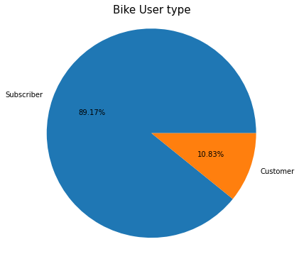

## (Visualization 2)

> The distribution of the weekly usage of the service shows that most of the trips were on weekdays as the number of trips on weekends dropped significantly. However,since there are two categories of users,there is a need to check the usage of each

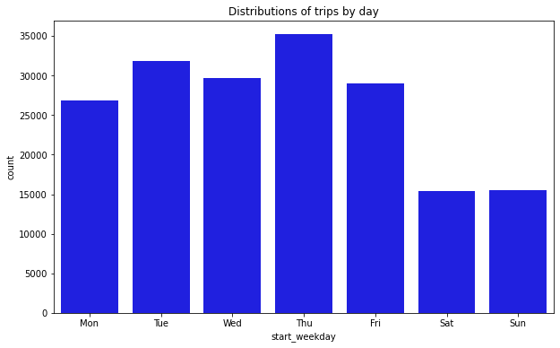

## (Visualization 3)

> While the number of bike-sharing for subscribers decrease drastically during weekends,there isn't significant difference in bike-sharing during weekdays and weekends among customers. We can deduce from the chart below that subscribers use the service more on weekdays. This best explains the point that there are more overall trips on weekdays than weekdays since there are more subscribers than customers. Let's explore the duration spent of trips by each users weekly

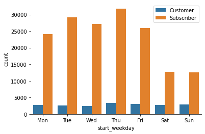

## Visualization 4

> It can be seen that Customers spend more time on the trips than subscribers and during weekends,the duration of trips increased significantly for customers. The duration of trips of subscribers is around 10mins with a slight increase on weekends. This indicate that subscribers seems to have a specific constant reason for usage of the bike-sharing system

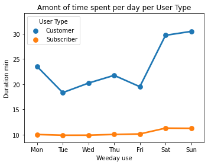